# Pitcher card

# Luinder Avila

RHP · KC

2026 · 21 G (13 GS) · 1,293 pitches · Apr 04 – Aug 01, 2026

Independent portfolio sample by Devin Jenkinson, not affiliated with any club. Every number is computed from public Statcast data.

Three big takeaways

1Attack

The slider is the put-away pitch. Use it to finish at-bats.

33% of two-strike pitches · 30% whiffs/swing (57 swings)

It grades 112 Stuff+. No other pitch has 50+ two-strike swings yet.

2Avoid

Limit the curveball. It is his most damaging pitch.

xRV/100 -0.31 shrunk (raw -0.56) · .403 xwOBAcon · 191 pitches

When behind in the count he throws it 9% of the time; the sinker grades -0.05 there instead.

3Watch

After the slider, hitters chase the curveball most.

31% chased on 100 out-of-zone pitches

Fastball height splits are too thin to call (40 swings up, 73 down).

Charts

### Movement

The CU finishes 24 in from his SI, with 19 in more glove-side run.

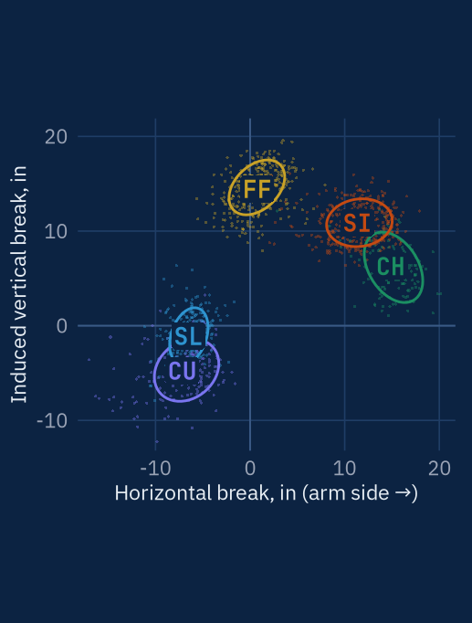

n = 1,293 pitches. Ellipses hold about 68% of each type; codes sit at the averages.

### Location by count

He throws 50% of pitches in the zone when behind and 36% when ahead.

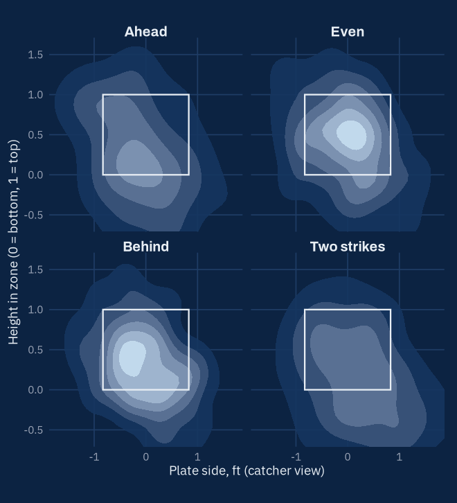

n = 1,293. Ahead 153 · even 450 · behind 327 · two strikes 363 pitches. Box = rule-book zone.

### Put-away

The SL is 33% of two-strike pitches vs 22% overall.

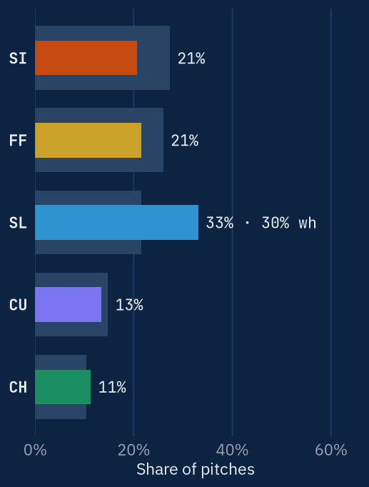

Two-strike n: SL 120, FF 78, SI 75, CU 49, CH 41. Grey bars = overall usage; wh = whiffs per swing (shown with 50+ swings).

### Arsenal

| Pitch | # | Use | Velo | IVB | HB | VAA | Whiff | Chase | xwOBAcon | xRV/100 | Stuff+ |
| --- | --- | --- | --- | --- | --- | --- | --- | --- | --- | --- | --- |
| Sinker (SI) | 353 | 27% | 96.4 | 10.9 | +11.4 | -6.1 | 18% | 27% | .346 | -0.05 | 100 |
| 4-Seam (FF) | 336 | 26% | 96.1 | 14.5 | +0.8 | -5.2 | 16% | 22% | .348 | -0.06 | 104 |
| Slider (SL) | 279 | 22% | 88.1 | -1.1 | -6.5 | -8.2 | 35% | 31% | .364 | -0.23 | 112 |
| Curveball (CU) | 191 | 15% | 83.0 | -4.7 | -7.2 | -8.8 | 24% | 31% | .403 | -0.31 | 100 |
| Changeup (CH) | 134 | 10% | 89.5 | 6.3 | +14.9 | -7.4 | 38% | 24% | .404 | -0.26 | 105 |

IVB / HB in inches (HB + = arm side). VAA in degrees at the front of the plate. xRV/100 = expected run value per 100 pitches, pitcher’s view, shrunk with a 250-pitch prior. Stuff+ = this project’s shape-only model (100 = MLB average, 10 = 1 SD).

### Vs. batter hand

| Pitch | LHH # | Use | Whiff | xwOBAcon | RHH # | Use | Whiff | xwOBAcon |
| --- | --- | --- | --- | --- | --- | --- | --- | --- |
| SI | 184 | 24% | 23% | .351 | 169 | 32% | 12% | .379 |
| FF | 216 | 28% | 13% | .336 | 120 | 23% | – | .363 |
| SL | 87 | 11% | – | .164 | 192 | 37% | 36% | .370 |
| CU | 147 | 19% | 24% | .391 | 44 | 8% | – | .366 |
| CH | 134 | 17% | 38% | .285 | – | – | – | – |

Use = share of pitches to that side. Whiff = whiffs per swing, shown with 50+ swings.